# HW-MD05

Author

Kiran Nagar

# HW-MD 05

```r
library(tidyverse)
twitch_data <- read_csv('twitchdata-update.csv')
```

I read in the data as instructed.

```r
library(janitor)
twitch_data <- clean_names(twitch_data)
colnames(twitch_data)
```

```
 [1] "channel"             "watch_time_minutes"  "stream_time_minutes"
 [4] "peak_viewers"        "average_viewers"     "followers"
 [7] "followers_gained"    "views_gained"        "partnered"
[10] "mature"              "language"
```

They look so much better! Let’s analyze.

## Question 1

```r
top_five <- twitch_data %>%
  sample_n(size = 5) %>%
  select(channel,
         average_viewers,
         followers)
top_five
```

```
# A tibble: 5 × 3
  channel      average_viewers followers
  <chr>                  <dbl>     <dbl>
1 EmadGG                  2741    702744
2 FollowGrubby            3365    430649
3 Baiano                  9229    425797
4 ONSCREEN                4134    918654
5 PsheroTV                1166    202779
```

```r
twitch_data %>%
  select(average_viewers, followers) %>%
  summary()
```

```
 average_viewers    followers
 Min.   :   235   Min.   :   3660
 1st Qu.:  1458   1st Qu.: 170546
 Median :  2425   Median : 318063
 Mean   :  4781   Mean   : 570054
 3rd Qu.:  4786   3rd Qu.: 624332
 Max.   :147643   Max.   :8938903
```

There is a huge range in minimum and maximum `average_viewers` as well as `followers`, but there seem to be some outliers at the high end due to the 3rd Quartile value compared to the max.

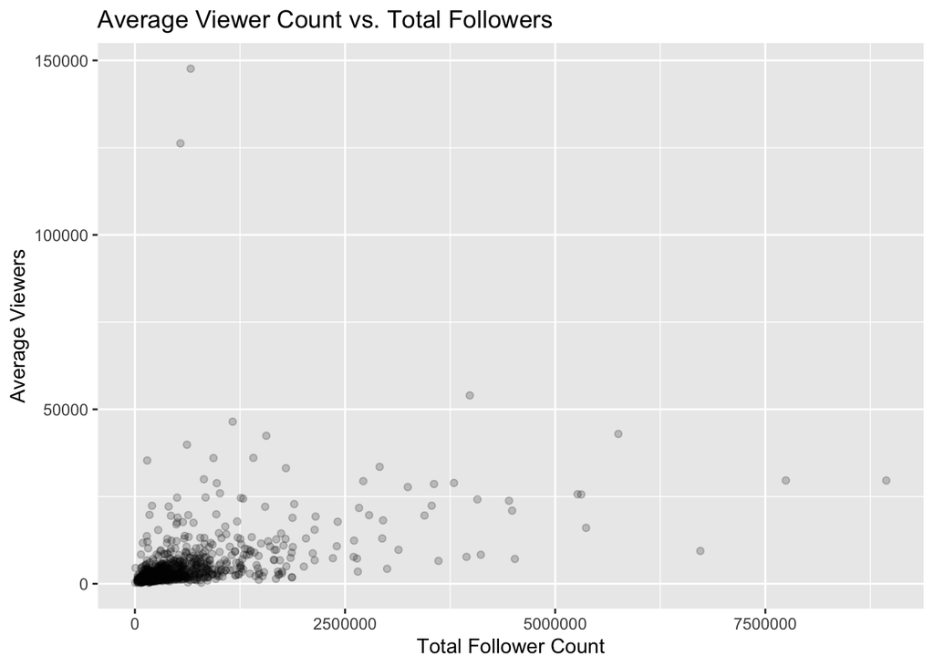

```r
ggplot(twitch_data, aes(x = followers,
                        y = average_viewers)) +
  geom_jitter(alpha = 0.2) +
  labs(title = "Average Viewer Count vs. Total Followers",
       x = "Total Follower Count",
       y = "Average Viewers")
```

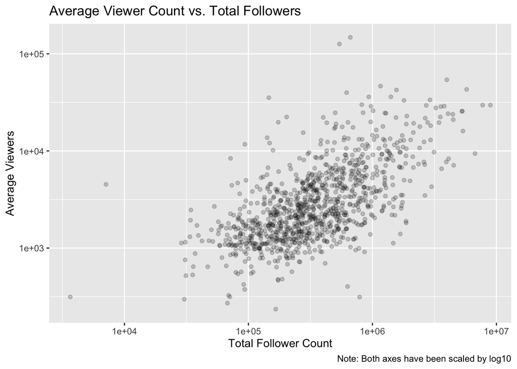

```r
ggplot(twitch_data, aes(x = followers,
                        y = average_viewers)) +
  geom_jitter(alpha = 0.2) +
  scale_x_log10() +
  scale_y_log10() +
  labs(title = "Average Viewer Count vs. Total Followers",
       x = "Total Follower Count",
       y = "Average Viewers",
       caption = "Note: Both axes have been scaled by log10")
```

Now, it looks like there is a strong relationship between total follower count and average viewers. I could envision a linear regression that would be close to a great number of these points—that being said, I could also envision an exponential curve that would model this data closely. This will be something to pay attention to.

```r
twitch_data <- twitch_data %>%
  mutate(log_viewers = log10(average_viewers),
         log_followers = log10(followers))
```

## Question 2

```r
fit1 <- lm(log_viewers ~ log_followers,
           data = twitch_data)
broom::tidy(fit1)
```

```
# A tibble: 2 × 5
  term          estimate std.error statistic   p.value
  <chr>            <dbl>     <dbl>     <dbl>     <dbl>
1 (Intercept)      0.198    0.125       1.58 1.15e-  1
2 log_followers    0.588    0.0226     26.0  1.69e-114
```

```r
fit1
```

```
Call:
lm(formula = log_viewers ~ log_followers, data = twitch_data)

Coefficients:
  (Intercept)  log_followers
       0.1978         0.5885
```

$1.1^{0.59} = 1.0578$

A 10% increase in followers is associated with a 5.78% increase in the average number of viewers.

## Question 3

```r
pred_data <- broom::augment(fit1)

glimpse(pred_data)
```

```
Rows: 1,000
Columns: 8
$ log_viewers   <dbl> 4.442731, 4.408410, 4.040444, 3.887280, 4.471321, 4.6275…
$ log_followers <dbl> 6.511388, 6.725108, 6.247393, 6.596030, 6.951284, 6.1940…
$ .fitted       <dbl> 4.029761, 4.155534, 3.874400, 4.079572, 4.288638, 3.8430…
$ .resid        <dbl> 0.4129697, 0.2528757, 0.1660436, -0.1922928, 0.1826833, …
$ .hat          <dbl> 0.006194481, 0.008694557, 0.003782169, 0.007126066, 0.01…
$ .sigma        <dbl> 0.3085580, 0.3087321, 0.3087919, 0.3087764, 0.3087820, 0…
$ .cooksd       <dbl> 0.0056128779, 0.0029688873, 0.0005513456, 0.0014026033, …
$ .std.resid    <dbl> 1.3420109, 0.8227954, 0.5389316, -0.6251793, 0.5953620, …
```

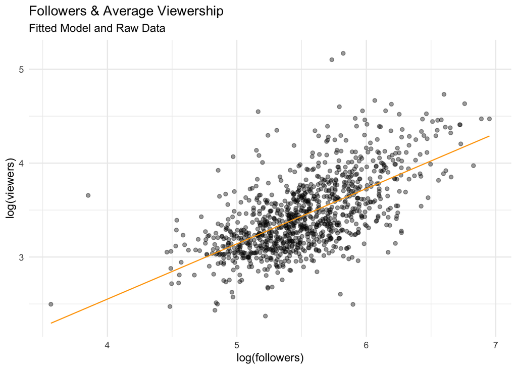

```r
pred_data %>%
  ggplot(aes(x = log_followers,
             y = log_viewers)) +
  geom_jitter(alpha = 0.4) +
  geom_line(aes(x = log_followers,
                y = .fitted),
            col = "orange") +
  theme_minimal() +
  labs(subtitle = "Fitted Model and Raw Data",
       title = "Followers & Average Viewership",
       x = "log(followers)",
       y = "log(viewers)")
```

It looks like the model describes the relationship fairly well—however, I look at the right half of the graph, and I feel like I see the data points above the curve getting further and further from our model line. This gives me pause, and I’m curious to see the residuals.

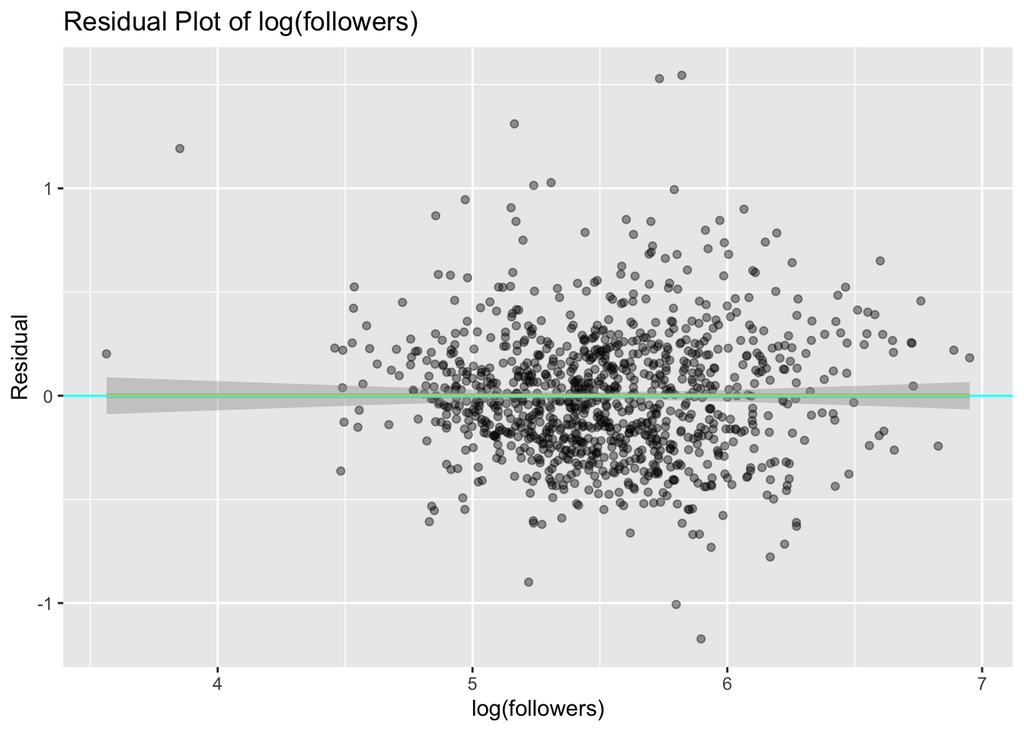

```r
ggplot(pred_data,
       aes(x = log_followers,
           y = .resid)) +
  geom_point(alpha=0.4) +
  geom_smooth(method=lm,
              col="orange") +
  geom_hline(yintercept = 0,
             col="cyan") +
  labs(title = "Residual Plot of log(followers)",
       x = "log(followers)",
       y = "Residual")
```

## Question 4

```r
language_sample <- twitch_data %>%
  sample_n(size = 5) %>%
  select(channel,
         language,
         average_viewers)
language_sample
```

```
# A tibble: 5 × 3
  channel             language   average_viewers
  <chr>               <chr>                <dbl>
1 Limmy               English               1641
2 Fairlight_Excalibur English               1208
3 Ko0416              Chinese               1515
4 c9judite            Portuguese             644
5 Rainbow6            English              11535
```

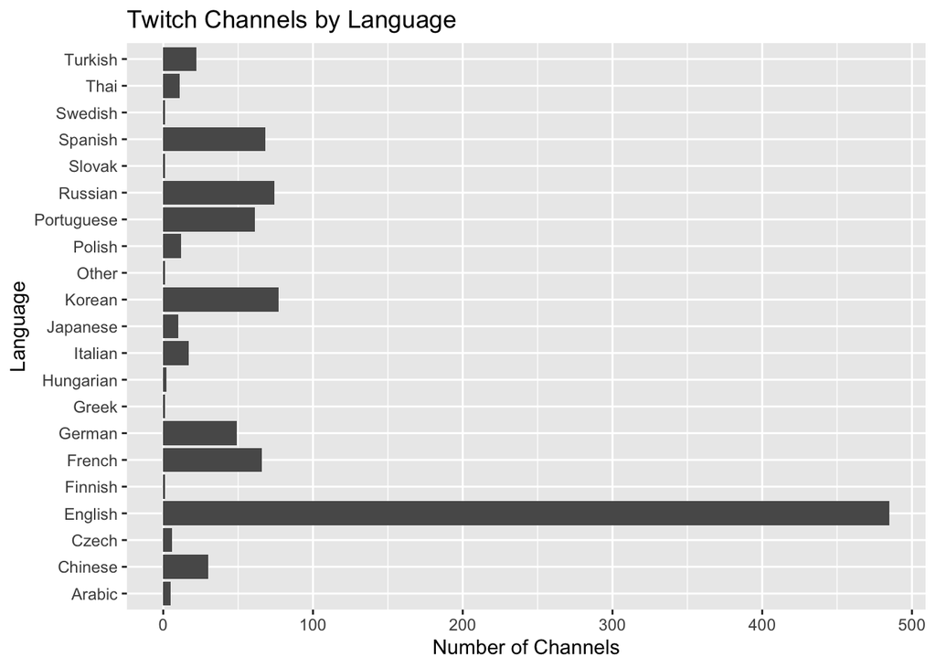

```r
ggplot(twitch_data,
       aes(x = language)) +
  geom_bar() +
  coord_flip() +
  labs(title = "Twitch Channels by Language",
       x = "Language",
       y = "Number of Channels")
```

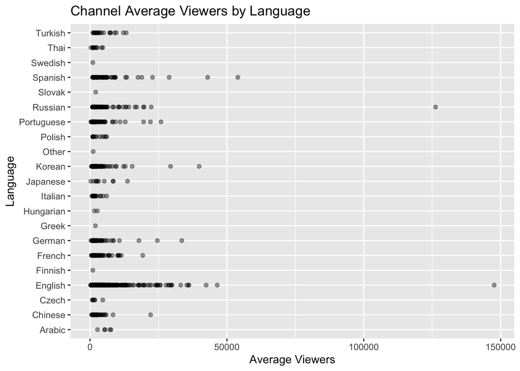

```r
ggplot(twitch_data,
       aes(x = language,
           y = average_viewers)) +
  geom_point(alpha = 0.4) +
  coord_flip() +
  labs(title = "Channel Average Viewers by Language",
       x = "Language",
       y = "Average Viewers")
```

Wow—English channels dominate in their share of the dataset. I wonder how this might impact the modeling. There is some interesting distribution when you examine some of the other languages.

```r
twitch_data %>% select(average_viewers) %>%
  summary()
```

```
 average_viewers
 Min.   :   235
 1st Qu.:  1458
 Median :  2425
 Mean   :  4781
 3rd Qu.:  4786
 Max.   :147643
```

```r
skimr::skim(twitch_data %>% group_by(language) %>% select(average_viewers))
```

Data summary

| Name | twitch_data %>% group_by(… |
| --- | --- |
| Number of rows | 1000 |
| Number of columns | 2 |
| _______________________ |  |
| Column type frequency: |  |
| numeric | 1 |
| ________________________ |  |
| Group variables | language |

**Variable type: numeric**

| skim_variable | language | n_missing | complete_rate | mean | sd | p0 | p25 | p50 | p75 | p100 | hist |
| --- | --- | --- | --- | --- | --- | --- | --- | --- | --- | --- | --- |
| average_viewers | Arabic | 0 | 1 | 5682.20 | 1957.83 | 2726 | 5305.00 | 5459.0 | 7265.00 | 7656 | ▃▁▇▁▇ |
| average_viewers | Chinese | 0 | 1 | 3424.80 | 3977.61 | 520 | 1437.75 | 2379.0 | 4204.25 | 22130 | ▇▁▁▁▁ |
| average_viewers | Czech | 0 | 1 | 1827.67 | 1430.04 | 780 | 1028.50 | 1376.0 | 1753.50 | 4642 | ▇▅▁▁▂ |
| average_viewers | English | 0 | 1 | 5112.81 | 9178.97 | 235 | 1458.00 | 2483.0 | 5001.00 | 147643 | ▇▁▁▁▁ |
| average_viewers | Finnish | 0 | 1 | 1027.00 | NA | 1027 | 1027.00 | 1027.0 | 1027.00 | 1027 | ▁▁▇▁▁ |
| average_viewers | French | 0 | 1 | 3506.53 | 3340.32 | 479 | 1659.25 | 2212.0 | 3920.75 | 19260 | ▇▁▁▁▁ |
| average_viewers | German | 0 | 1 | 4278.18 | 6098.39 | 326 | 1317.00 | 2181.0 | 4207.00 | 33514 | ▇▁▁▁▁ |
| average_viewers | Greek | 0 | 1 | 1961.00 | NA | 1961 | 1961.00 | 1961.0 | 1961.00 | 1961 | ▁▁▇▁▁ |
| average_viewers | Hungarian | 0 | 1 | 2140.50 | 774.28 | 1593 | 1866.75 | 2140.5 | 2414.25 | 2688 | ▇▁▁▁▇ |
| average_viewers | Italian | 0 | 1 | 2205.53 | 1543.61 | 636 | 1205.00 | 1505.0 | 2647.00 | 6073 | ▇▃▂▁▁ |
| average_viewers | Japanese | 0 | 1 | 4762.60 | 4194.28 | 271 | 2236.00 | 2907.0 | 7586.00 | 13675 | ▇▃▁▃▂ |
| average_viewers | Korean | 0 | 1 | 3913.88 | 5863.30 | 529 | 1402.00 | 2202.0 | 3992.00 | 39848 | ▇▁▁▁▁ |
| average_viewers | Other | 0 | 1 | 1149.00 | NA | 1149 | 1149.00 | 1149.0 | 1149.00 | 1149 | ▁▁▇▁▁ |
| average_viewers | Polish | 0 | 1 | 2905.25 | 1985.76 | 898 | 1121.00 | 2165.0 | 4640.25 | 6091 | ▇▃▂▂▅ |
| average_viewers | Portuguese | 0 | 1 | 3800.93 | 5035.63 | 315 | 1196.00 | 1914.0 | 4111.00 | 25918 | ▇▁▁▁▁ |
| average_viewers | Russian | 0 | 1 | 6594.23 | 14947.32 | 849 | 1824.50 | 2934.5 | 5698.25 | 126232 | ▇▁▁▁▁ |
| average_viewers | Slovak | 0 | 1 | 2072.00 | NA | 2072 | 2072.00 | 2072.0 | 2072.00 | 2072 | ▁▁▇▁▁ |
| average_viewers | Spanish | 0 | 1 | 6449.69 | 9057.98 | 897 | 1753.00 | 3917.5 | 6081.75 | 53986 | ▇▁▁▁▁ |
| average_viewers | Swedish | 0 | 1 | 1027.00 | NA | 1027 | 1027.00 | 1027.0 | 1027.00 | 1027 | ▁▁▇▁▁ |
| average_viewers | Thai | 0 | 1 | 2011.36 | 1380.76 | 314 | 1110.50 | 1363.0 | 2488.50 | 4629 | ▇▆▃▁▃ |
| average_viewers | Turkish | 0 | 1 | 4760.86 | 3622.15 | 1030 | 2133.75 | 3093.0 | 7351.75 | 13224 | ▇▂▂▁▁ |

Some of the other languages have more piece-wise distributions than English. That is, they are less continuous. However, I do see that most languages have a pretty solid block of channels at the low end of the spectrum.

## Question 5

```r
twitch_data <- twitch_data %>%
  mutate(language = as.factor(language),
         language = relevel(language, ref = "English"))
```

```r
fit2 <- lm(average_viewers ~ language,
           data = twitch_data)
broom::tidy(fit2)
```

```
# A tibble: 21 × 5
   term              estimate std.error statistic  p.value
   <chr>                <dbl>     <dbl>     <dbl>    <dbl>
 1 (Intercept)          5113.      385.    13.3   3.47e-37
 2 languageArabic        569.     3808.     0.150 8.81e- 1
 3 languageChinese     -1688.     1594.    -1.06  2.90e- 1
 4 languageCzech       -3285.     3480.    -0.944 3.45e- 1
 5 languageFinnish     -4086.     8480.    -0.482 6.30e- 1
 6 languageFrench      -1606.     1111.    -1.45  1.49e- 1
 7 languageGerman       -835.     1270.    -0.657 5.11e- 1
 8 languageGreek       -3152.     8480.    -0.372 7.10e- 1
 9 languageHungarian   -2972.     6002.    -0.495 6.21e- 1
10 languageItalian     -2907.     2090.    -1.39  1.65e- 1
# ℹ 11 more rows
```

```r
fit2
```

```
Call:
lm(formula = average_viewers ~ language, data = twitch_data)

Coefficients:
       (Intercept)      languageArabic     languageChinese       languageCzech
            5112.8               569.4             -1688.0             -3285.1
   languageFinnish      languageFrench      languageGerman       languageGreek
           -4085.8             -1606.3              -834.6             -3151.8
 languageHungarian     languageItalian    languageJapanese      languageKorean
           -2972.3             -2907.3              -350.2             -1198.9
     languageOther      languagePolish  languagePortuguese     languageRussian
           -3963.8             -2207.6             -1311.9              1481.4
    languageSlovak     languageSpanish     languageSwedish        languageThai
           -3040.8              1336.9             -4085.8             -3101.5
   languageTurkish
            -352.0
```

Arabic, Russian, and Spanish are the three languages whose coefficients indicate that they have more average viewers than English. The prediction is fairly accurate—another thing to consider is the fact that there were so many more English channels than there were other languages. I would be curious how that might change if we were to take the top 1000 channels in each country and perform the same analysis.

## Question 6

[figure not shown]

```r
resid_data <- broom::augment(fit2)
ggplot(resid_data,
       aes(x = average_viewers,
           y = .resid,
           color = language)) +
  geom_point(alpha=0.4) +
  scale_x_log10() +
  geom_smooth(method=lm,
              col="orange") +
  geom_hline(yintercept = 0,
             col="cyan") +
  labs(title = "Residual Plot of log(followers) by language",
       x = "log(followers)",
       y = "Residual")
```

It looks like there are two outliers—it appears to be the English and Russian versions of the channel `dota2i.`